# An exercise on comparing maximum likelihood, Bayes and empirical Bayes

##### CS4070 - WI4455 (Frank van der Meulen - Delft University of Technology)

##### November 2020

In this exercise we consider the model

\[ X_i \mid \Theta_i = \theta_i \stackrel{ind}{\sim} Unif(0,\theta_i)\\ \Theta_1,\ldots, \Theta_n \stackrel{iid}{\sim} Ga(2,\lambda) \]

Here $\lambda$ will initially be considered as a hyperparameter (that is, fixed – known). Note that the classical (frequentist) model does not involve a prior and is given by

\[ X_1,\ldots, X_n \stackrel{iid}{\sim} Unif(0\theta_i) \]

It is easily verified that the mle for $\theta_i$ is given by $x_i$ (just make a sketch of the likelihood function). Here we compare the mle with various estimators derived from the Bayesian setup. For this model, one can show that conditional on $X_1,\ldots, X_n$, the random variables $\Theta_1,\ldots, \Theta_n$ are independent and that $\Theta_i \mid X_i \sim X_i + Z_i$, where $\{Z_i,\, 1\le i\le n\} \stackrel{iid}{\sim} Exp(\lambda)$, independent of all other random variables. In particular, the posterior mean satisfies $E[\Theta_i \mid X_i] = X_i + 1/\lambda$. Furthermore, one can show that the empirical Bayes estimate (obtained by maximum likelihood type II) for $\lambda$ equals $1/\bar{X}_n$.

To study the estimators numerically, we f irst load some packages.

```julia
using DataFrames
using LinearAlgebra
using Distributions
using Cairo
using Gadfly
```

Let's generate some artifical data to work with. In the following `n` will denote the sample size. The "true" $\theta$ values are generated by drawing independently from the uniform distribution on $[0,1000]$. So here we go

```julia
n = 100
θ₀ = rand(Uniform(0,1000.0),n);
```

So here are the true values displayed

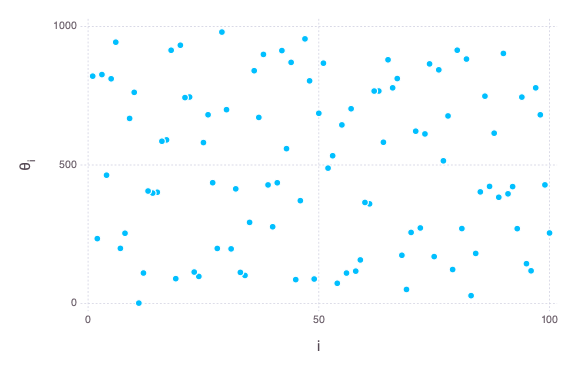

```julia
Gadfly.plot(x=collect(1:n), y=θ₀, Guide.xlabel("i"), Guide.ylabel("θᵢ"))
```

Now the data are obtained from

```julia
x = [rand(Uniform(0,θ₀[i])) for i ∈ eachindex(θ₀)];
```

Note that I use the `Gadfly` plotting package here. It is somewhat similar to ``ggplot2` in `R`. The estimators are easily computed

```julia
mle = x;
ebayes = x .+ mean(x);
λ = 0.010 # hyperpar in prior
bayes = x .+ 1.0/λ;
```

Now the performance of the three estimators can be compared by computed the sum of the squared deviations between the estimates and true values:

```julia
ss(x) = sum(x.^2)
D = DataFrame(method = ["mle", "bayes", "ebayes"],
      ss = [ss(mle-θ₀),ss(bayes-θ₀),ss(ebayes-θ₀)])
print(D)
```

```
3×2 DataFrame
 Row │ method  ss
     │ String  Float64
─────┼───────────────────
   1 │ mle     1.32027e7
   2 │ bayes   8.84186e6
   3 │ ebayes  6.15776e6
```

To make the comparison slightly easier, let's add a column, taking mle as benchmark.

```julia
D[!,:ss_rel] = D[!,:ss]./D[1,:ss];
print(D)
```

```
3×3 DataFrame
 Row │ method  ss         ss_rel
     │ String  Float64    Float64
─────┼─────────────────────────────
   1 │ mle     1.32027e7  1.0
   2 │ bayes   8.84186e6  0.6697
   3 │ ebayes  6.15776e6  0.466401
```

So it is definitely worthwhile considering empirical Bayes here!. The performance of the truly Bayesian method where the posterior mean depends on $\lambda$ is of course hugely dependent on the choice of this parameter. Clearly, if $\lambda$ is large, the posterior mean and mle will be about the same. Finally, we visualise the estimators

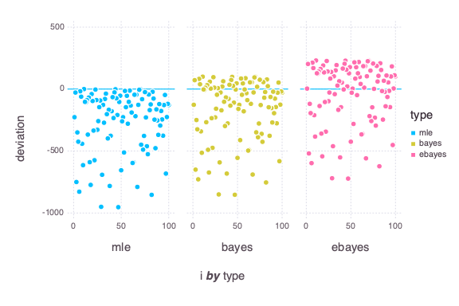

```julia
d = DataFrame(i=repeat(1:n,outer=3),
              deviation = vcat(mle - θ₀, bayes - θ₀, ebayes - θ₀),
              type = repeat(["mle", "bayes", "ebayes"], inner=n))
p = Gadfly.plot(d, x=:i, y=:deviation, color=:type, xgroup=:type,
      yintercept=[0.0],
      Geom.subplot_grid(Geom.point, Geom.hline ))
```

## Fully Bayesian approach by employing a prior on $\lambda$

Instead of empirical Bayes, we can add an additional layer to the Bayesian model specification. Such a thing is wise when it is noticed that the posterior is much influenced by the choice of a hyperparameter ($\lambda$ in this case). Let's assume a slightly different model, where $\lambda$ is not a hyperparameter, but $\lambda \sim \mbox{Ga}(\alpha, \beta)$.

\[ X_i \mid \Theta_i = \theta_i \stackrel{ind}{\sim} Unif(0,\theta_i)\\ \Theta_1,\ldots, \Theta_n \mid \Lambda=\lambda \stackrel{iid}{\sim} Ga(2,\lambda)\\ \Lambda \sim Ga(\alpha, \beta) \]

So now $\alpha$ and $\beta$ are hyperparameters in the model.

```julia
α = 1.0
β = 1.0
```

```
1.0
```

One can take other values later. For now notice that the prior mean of $\lambda$ equals $\alpha/ \beta =1$. We run a Gibbs sampler, in which the $\theta_i$ and $\lambda$ are updated in separate steps. The steps are quite easy:

```julia
IT = 10000  # number of iterations
λ = [α/β]   # initialise with prior mean
θ = zeros(IT,n) # each row contains an MCMC iteration
for it in 2:IT
    θ[it,:] = x .+ rand(Exponential(1/λ[it-1]))
    β_ = β + sum(θ[it,:])
    push!(λ, rand(Gamma(2*n + α, 1.0/β_)))
end
```

[In `julia` the Exponential and Gamma distributions use a parametrisation in terms of the scale parameter, not the rate parameter. One should always be careful in this.] Let's first check that the chain has *converged* to its stationary region (one can never make the claim with certainty, but we can check if there are obvious deviations from stationarity). So we make a trace plot for $\lambda$.

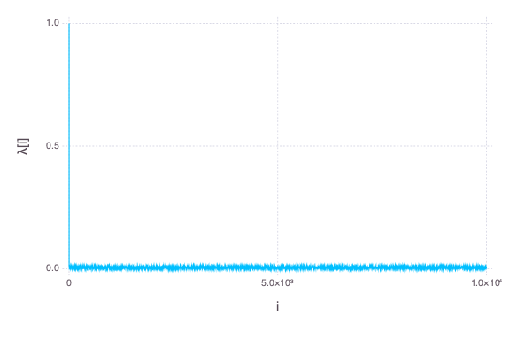

```julia
Gadfly.plot(x=1:IT, y = λ, Geom.path,
      Guide.xlabel("i"), Guide.ylabel("λ[i]"))
```

This looks perfectly fine! The chain reaches its stationary regime almost instantly. Also note that apparently we learn about the value of $\lambda$. Whereas a priori it was $1.0$, aposteriori it is on average about $0.005$. This is not too far from $1/\bar{x}_n \approx 0.0043$. Keep that in mind when rereading this post and comparing empirical Bayes with full Bayes using a prior on $\lambda$.

To check the chain, also trace plots for all $\theta_i$ could be made... However, there are many parameters, so we are not going to check all. Let's consider the third parameter

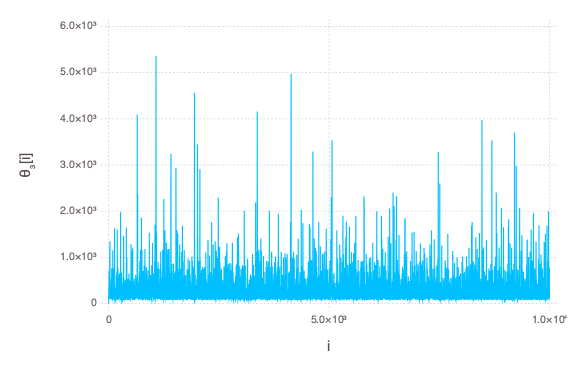

```julia
Gadfly.plot(x=1:IT, y=θ[:,3], Geom.path,
      Guide.xlabel("i"), Guide.ylabel("θ₃[i]"))
```

The posterior distribution for this coefficient seems skewed, so taking a log-transformation may tidy up the traceplot a bit.

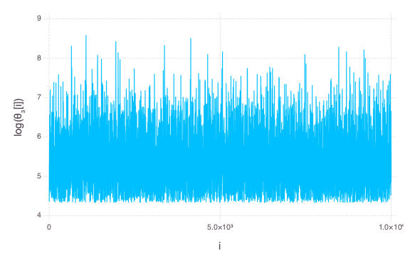

```julia
Gadfly.plot(x=1:IT, y=log.(θ[:,3]), Geom.path,
      Guide.xlabel("i"), Guide.ylabel("log(θ₃[i])"))
```

```julia
log(x[3])
```

```
4.3298580723918185
```

We consider the first half of the iterations as burnin, and compute the average of the remainder of the samples.

```julia
its = div(IT,2):IT
θ̂ = [mean(x[its]) for x ∈ eachcol(θ)]
λ̂ = mean(λ[its])
```

```
0.005412583988862436
```

For plotting purposes, we add the results of $\hat\theta$ to the dataframe `d`.

```julia
d_ = DataFrame(i=1:n, deviation= θ̂ - θ₀, type=fill("hierbayes",n))
append!(d,d_);
```

Next, we can redo the plotting

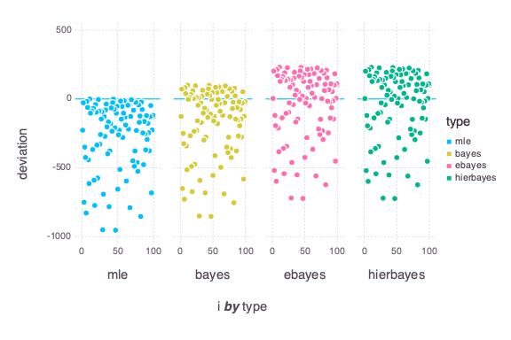

```julia
p = Gadfly.plot(d, x=:i, y=:deviation, color=:type, xgroup=:type,
      yintercept=[0.0],
      Geom.subplot_grid(Geom.point, Geom.hline ))
```

It is clear that the fully Bayesian approach and empirical Bayes give similar point estimates. Now the Bayesian approach gives full uncertainty quantification. For example, for $\theta_1$ we can make a histogram of the posterior samples

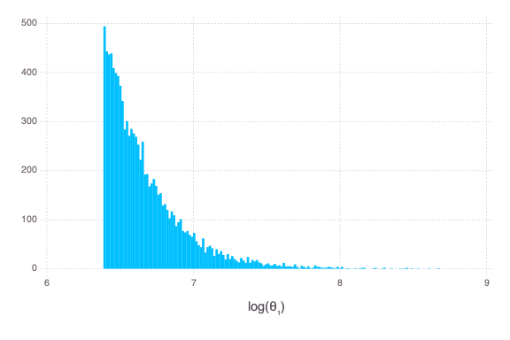

```julia
lθ1 = log.(θ[:,1])
Gadfly.plot(x=lθ1, Geom.histogram, Guide.xlabel("log(θ₁)"), Guide.ylabel(""))
```

Published from exer_4_20.jmd using Weave.jl v0.10.6 on 2020-12-01.